# KOICA WFK 파견인원

4주차 퀴즈(1)

Author

최요한

Published

June 25, 2026

# 1 준비사항

## 1.1 tidyverse 로드

> 항상 tidyverse를 로드합니다.

```r
library(tidyverse)            # 라이브러리 로드
```

## 1.2 showtext 로드

> 한글을 오류없이 출력할수 있습니다

```r
# install.packages("showtext")        # 최초 1회
library(showtext)                     # 라이브러리 로드
showtext_auto()
```

## 1.3 자료 출처

출처: [공공데이터포탈](https://www.data.go.kr/data/15051101/fileData.do)

[figure not shown]

KOICA 해외봉사단 파견현황

## 1.4 변수에 저장하기

> 변수명: koica_wfk_20260331

```r
read_csv("./koica_wfk_20260331.csv") ->  koica_wfk_20260331
koica_wfk_20260331 -> koica_1csv
```

## 1.5 데이터셋 출력

```r
koica_1csv
```

```
# A tibble: 196 × 6
    연도 단원형태   국가명 파견직종         파견분야        인원
   <dbl> <chr>      <chr>  <chr>            <chr>          <dbl>
 1  2026 일반봉사단 가나   유아교육         교육               2
 2  2026 일반봉사단 가나   전기/전력        기술환경에너지     1
 3  2026 일반봉사단 가나   체육교육(일반)   교육               1
 4  2026 일반봉사단 가나   컴퓨터교육(일반) 교육               1
 5  2026 일반봉사단 가나   한국어교육(일반) 교육               1
 6  2026 일반봉사단 네팔   관광             공공행정           1
 7  2026 일반봉사단 네팔   사회복지         공공행정           1
 8  2026 일반봉사단 네팔   유아교육         교육               1
 9  2026 일반봉사단 네팔   임상병리         보건의료           1
10  2026 일반봉사단 네팔   자동차           기술환경에너지     1
# ℹ 186 more rows
```

# 2 기초 문제

## 2.1 데이터셋의 구조를 출력하시오

> glimpse()

```
Rows: 196
Columns: 6
$ 연도     <dbl> 2026, 2026, 2026, 2026, 2026, 2026, 2026, 2026, 2026, 2026, 2…
$ 단원형태 <chr> "일반봉사단", "일반봉사단", "일반봉사단", "일반봉사단", "일반봉사단", "일반봉사단", "일반봉사단"…
$ 국가명   <chr> "가나", "가나", "가나", "가나", "가나", "네팔", "네팔", "네팔", "네팔", "네팔", "…
$ 파견직종 <chr> "유아교육", "전기/전력", "체육교육(일반)", "컴퓨터교육(일반)", "한국어교육(일반)", "관광", …
$ 파견분야 <chr> "교육", "기술환경에너지", "교육", "교육", "교육", "공공행정", "공공행정", "교육", "보건의…
$ 인원     <dbl> 2, 1, 1, 1, 1, 1, 1, 1, 1, 1, 2, 1, 2, 2, 2, 1, 1, 1, 2, 1, 1…
```

## 2.2 ’국가명’을 기준으로 파견인원 현황표를 출력하시오

> count(국가명)

```
# A tibble: 33 × 2
   국가명             n
   <chr>          <int>
 1 가나               5
 2 네팔               8
 3 도미니카공화국     4
 4 동티모르          12
 5 라오스             9
 6 르완다             8
 7 모로코            11
 8 몽골               9
 9 방글라데시         2
10 베트남             9
# ℹ 23 more rows
```

## 2.3 ’국가명’을 기준으로 파견인원 현황표를 (엑셀)표처럼 출력하시오

> view()

## 2.4 ’파견분야’와 ’파견직종’을 기준으로 파견인원 현황표를 출력하시오

> count(파견분야, 파견직종)

```
# A tibble: 45 × 3
   파견분야 파견직종          n
   <chr>    <chr>         <int>
 1 공공행정 공공행정 일반     2
 2 공공행정 관광              4
 3 공공행정 국제개발          3
 4 공공행정 디지털미디어      5
 5 공공행정 사회복지          8
 6 공공행정 신문/방송         1
 7 교육     과학교육          3
 8 교육     미술교육          7
 9 교육     미용교육          3
10 교육     사서              1
# ℹ 35 more rows
```

# 3 보통 문제

## 3.1 네팔에 파견되는 관측값을 모두 출력하시오

> filter(국가명 == ‘네팔’)

```
# A tibble: 8 × 6
   연도 단원형태   국가명 파견직종         파견분야        인원
  <dbl> <chr>      <chr>  <chr>            <chr>          <dbl>
1  2026 일반봉사단 네팔   관광             공공행정           1
2  2026 일반봉사단 네팔   사회복지         공공행정           1
3  2026 일반봉사단 네팔   유아교육         교육               1
4  2026 일반봉사단 네팔   임상병리         보건의료           1
5  2026 일반봉사단 네팔   자동차           기술환경에너지     1
6  2026 일반봉사단 네팔   초등교육         교육               2
7  2026 일반봉사단 네팔   특수교육         교육               1
8  2026 일반봉사단 네팔   한국어교육(일반) 교육               2
```

## 3.2 파견분야에서 ‘보건의료’ 파견인원이 많은 순서대로 출력하시오

> filter(파견분야 == ‘보건의료’), arrange

```
# A tibble: 32 × 6
    연도 단원형태   국가명         파견직종      파견분야  인원
   <dbl> <chr>      <chr>          <chr>         <chr>    <dbl>
 1  2026 일반봉사단 볼리비아       간호          보건의료     4
 2  2026 일반봉사단 라오스         간호          보건의료     3
 3  2026 일반봉사단 캄보디아       간호          보건의료     3
 4  2026 일반봉사단 도미니카공화국 간호          보건의료     2
 5  2026 일반봉사단 르완다         간호          보건의료     2
 6  2026 일반봉사단 모로코         보건의료 일반 보건의료     2
 7  2026 일반봉사단 베트남         간호          보건의료     2
 8  2026 일반봉사단 에티오피아     간호          보건의료     2
 9  2026 일반봉사단 피지           간호          보건의료     2
10  2026 일반봉사단 피지           치위생        보건의료     2
# ℹ 22 more rows
```

## 3.3 피지(피지) 국가에서 ‘축산’ 직종이 속한 파견분야는 무엇입니까?

> filter, &

[output not shown]

```
# A tibble: 1 × 3
  국가명 파견직종 파견분야
  <chr>  <chr>    <chr>
1 피지   축산     농림수산
```

## 3.4 ‘가나’와 ’네팔’의 ’유아교육’ 파견 인원을 합산하면 총 몇 명입니까?

> filter(국가명 %in% c(‘가나’, ‘네팔’), 파견직종 == ‘유아교육’)

```
# A tibble: 1 × 1
   합계
  <dbl>
1     3
```

## 3.5 ’파견분야’별로 파견인원 합계를 출력하시오

> group_by(파견분야) |> reframe(합계 = sum(인원))

```
# A tibble: 5 × 2
  파견분야        합계
  <chr>          <dbl>
1 공공행정          28
2 교육             246
3 기술환경에너지    24
4 농림수산           9
5 보건의료          46
```

## 3.6 ‘르완다’, ‘모로코’, ‘에콰도르’에 파견되는 ’사회복지’ 인원의 합계는 얼마입니까?

> filter(국가명 %in% c(‘르완다’, ‘모로코’, ‘에콰도르’))

```
# A tibble: 1 × 2
  파견직종 `sum(인원)`
  <chr>          <dbl>
1 사회복지           5
```

## 3.7 파견분야별 파견인원은 얼마입니까?

> group_by(파견분야), reframe(), sum()

```
# A tibble: 5 × 2
  파견분야        합계
  <chr>          <dbl>
1 공공행정          28
2 교육             246
3 기술환경에너지    24
4 농림수산           9
5 보건의료          46
```

## 3.8 파견분야별 파견인원을 막대그래프로 시각화하시오

> ggplot(), geom_bar(stat = ’identity)

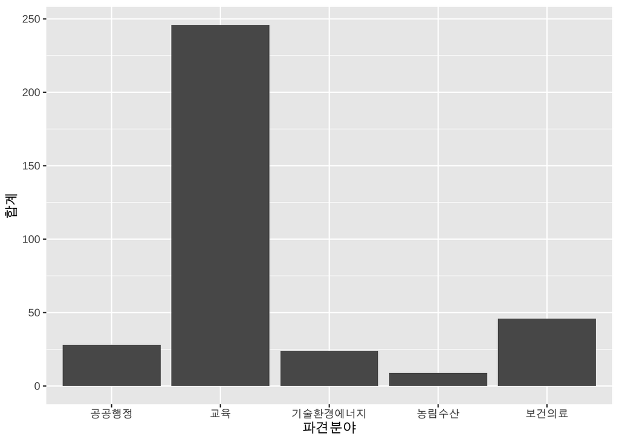

**한글이 안나올 경우**

```r
library(showtext)
showtext_auto()
```

# 4 어려움 문제

## 4.1 단일 국가 기준으로 총 인원 30명을 초과하는 국가는 어디입니까?

> group_by(국가명), reframe(인원합계 = sum(인원))

```
# A tibble: 1 × 2
  국가명 인원합계
  <chr>     <dbl>
1 페루         31
```

## 4.2 해외 파견 ’국가’는 총 몇 개인가요? (중복 제외)

> distinct(국가명)

```
# A tibble: 1 × 1
      n
  <int>
1    33
```

## 4.3 ‘한국어교육(일반)’ 직종의 파견 인원 합계를 국가별로 그룹화했을 때, 인원수가 가장 많은 국가는 어디인가요?

> filter, agrepl, group_by, reframe, arrange

```
# A tibble: 23 × 2
   국가명        합계
   <chr>        <dbl>
 1 태국            16
 2 베트남          13
 3 이집트          13
 4 페루            11
 5 모로코           8
 6 몽골             8
 7 캄보디아         7
 8 방글라데시       6
 9 키르기스스탄     6
10 동티모르         5
# ℹ 13 more rows
```

[output not shown]

## 4.4 동티모르의 데이터를 ’파견분야’로 그룹화하여 인원수를 합산했을 때, 가장 많은 인원이 배정된 분야는 무엇인가요?

> filter, group_by, reframe

```
# A tibble: 4 × 2
  파견분야        합계
  <chr>          <dbl>
1 공공행정           3
2 교육              11
3 기술환경에너지     3
4 보건의료           1
```

## 4.5 ’탄자니아’와 ’모로코’에 공통적으로 파견되는 ’파견분야’가 아닌 것은 무엇입니까?

> filter, distinct, unique

```
# A tibble: 7 × 2
  국가명   파견분야
  <chr>    <chr>
1 모로코   기술환경에너지
2 모로코   공공행정
3 모로코   교육
4 모로코   보건의료
5 탄자니아 보건의료
6 탄자니아 교육
7 탄자니아 공공행정
```

## 4.6 ‘한국어교육(일반) 및 한국어 교육(심화)’ 파견 인원은 총 몇 명입니까?

> filter

```
# A tibble: 31 × 6
    연도 단원형태   국가명     파견직종              파견분야  인원
   <dbl> <chr>      <chr>      <chr>                 <chr>    <dbl>
 1  2026 일반봉사단 가나       한국어교육(일반)      교육         1
 2  2026 일반봉사단 네팔       한국어교육(일반)      교육         2
 3  2026 일반봉사단 동티모르   한국어교육(EPS-TOPIK) 교육         1
 4  2026 일반봉사단 동티모르   한국어교육(일반)      교육         5
 5  2026 일반봉사단 라오스     한국어교육(심화)      교육         4
 6  2026 일반봉사단 모로코     한국어교육(일반)      교육         8
 7  2026 일반봉사단 몽골       한국어교육(일반)      교육         8
 8  2026 일반봉사단 방글라데시 한국어교육(EPS-TOPIK) 교육         3
 9  2026 일반봉사단 방글라데시 한국어교육(일반)      교육         6
10  2026 일반봉사단 베트남     한국어교육(심화)      교육         1
# ℹ 21 more rows
```

## 4.7 가나, 에티오피아, 파라과이, 라오스 중 ‘간호’ 직종의 파견 인원이 없는 국가는 어디입니까?

> filter(국가명 %in% c(‘에티오피아’, ‘가나’, ‘파라과이’, ‘라오스’)) |> count(국가명, 파견직종, 파견분야)

```
# A tibble: 3 × 4
  국가명     파견직종 파견분야     n
  <chr>      <chr>    <chr>    <int>
1 라오스     간호     보건의료     1
2 에티오피아 간호     보건의료     1
3 파라과이   간호     보건의료     1
```

## 4.8 전체 국가 중에서 ‘태권도’ 관련 직종으로 파견되는 총 인원은 몇 명입니까?

> filter

```
# A tibble: 4 × 6
   연도 단원형태   국가명 파견직종         파견분야  인원
  <dbl> <chr>      <chr>  <chr>            <chr>    <dbl>
1  2026 일반봉사단 라오스 체육교육(태권도) 교육         1
2  2026 일반봉사단 베트남 체육교육(태권도) 교육         1
3  2026 일반봉사단 이집트 체육교육(태권도) 교육         1
4  2026 일반봉사단 페루   체육교육(태권도) 교육         1
```

# 5 매우 어려움 2개

## 5.1 파견분야가 ’보건의료’인 국가의 파견직종별 파견인원을 표로 출력하시오

> filter(), group_by, reframe

```
# A tibble: 32 × 4
   국가명         파견분야 파견직종          n
   <chr>          <chr>    <chr>         <dbl>
 1 네팔           보건의료 임상병리          1
 2 도미니카공화국 보건의료 간호              2
 3 동티모르       보건의료 간호              1
 4 라오스         보건의료 간호              3
 5 라오스         보건의료 방사선            1
 6 르완다         보건의료 간호              2
 7 모로코         보건의료 보건의료 일반     2
 8 베트남         보건의료 간호              2
 9 볼리비아       보건의료 간호              4
10 볼리비아       보건의료 치위생            1
# ℹ 22 more rows
```

## 5.2 파견분야가 ’보건의료’인 국가의 파견직종별 파견인원을 히트맵으로 그리고 값을 넣으시오

> filter, group_by(국가명, 파견직종), reframe(), ggplot, geom_tile, geom_text, theme_minimal

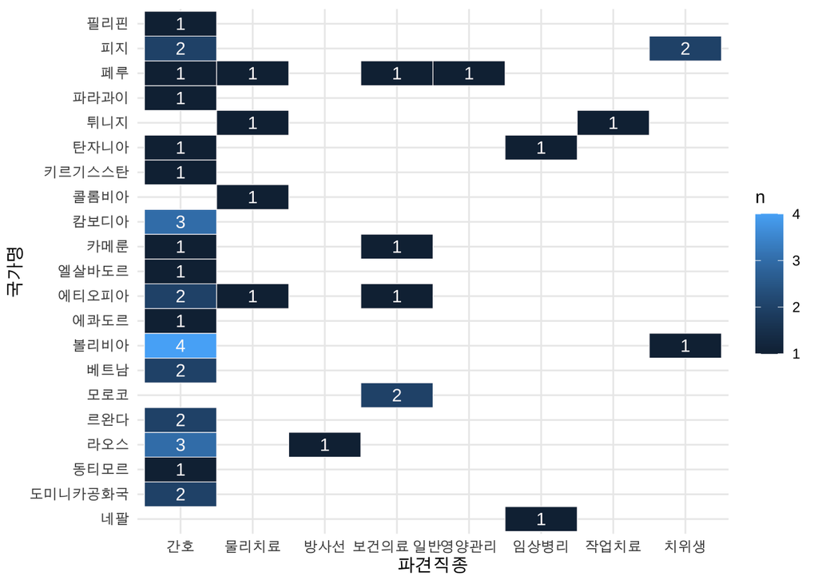